# Applied Machine Learning with R

March 27, 2019

## About the instructor

- Professor of Finance and System Information at Federal University of Paraiba (Brazil);
- My main interests: Predictive Analysis; Business Forecast; Asset Pricing
- Chief Data Scientist at [MECAPLAB](https://sites.google.com/view/mecaplab);
- Experience: Public and Private Sector;
- Programming Language: **R**, SQL and python;

## Why Machine Learning?

- Classical Statistics relies on **assumptions**:
1. Choose a model for the underlying law governing the observed phenomenon;
2. Use statistical tools to estimate unknown parameters;
3. Make predictions;
- However:
- Assumption is wrong \(\Rightarrow\) parameters estimates make no sense;
- Make prediction poorly;
- You might say: Ok… let’s choose a better hypothesis!
- There are a lot number of possible families of distributions;
- But what if the data has a huge number of features? How do we visualize this data to make a model proposition?
- The stage of modelisation is the most difficult part;
- In a nutshel: You can end up with poor \(\hat{f}(X)\);

## Why Machine Learning?

- What if I told you there might be a better data-driven approach?
- … and this data-driven approach will try to find appropriate transformation?

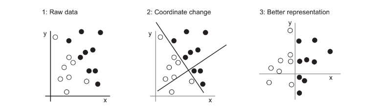

- … and this endeavor will be guided by a learning process?
- … and all this process wil be done by a computer (algorithm)?
- That’s Machine Learning:
1. a searching for useful representations of input data;
2. within an enhanced space of possibilities;
3. using guidance from a feedback signal;

[figure not shown]

## Supervised vs Unsupervised Learning

- *Supervised* or *Unsupervised*;
- **Supervised**:
  - For each *obs* of the predictor measurement(s) \(x_i\), there is a reponse \(y_i\);
  - The vast majority of ML applications are **supervised**;
- **Unsupervised** is more challenging:
  - for each *obs* \(i = 1, ..., n\), we do not observe \(y_i\);
  - examples: *cluster* analysis;
- **Semi-supervised**:
  - For \(m\) of the observations, where \(m < n\), we have both \(x\) and \(y\);
  - For \(n - m\) we have the \(x\) and do not have the \(y\);
  - Cluster the \(n\) *obs* into \(k\) distinct groups;
  - Use the labels for the \(m\) *obs* in this \(k\) groups to label the remaining ones.

## Regression vs Classification

- Variables can be characterized as *quantitative* and *qualitative*;
- **Quantitative**:
  - Take on numerical values;
  - ex: sales, income, value of a house, price of a stock;
  - linear model;
- **Qualitative**:
  - Take on values in one of \(K\) different categories;
  - ex: poverty, gender, default on debt, customer churn;
  - logistic/probit models;

## Bias-variance trade-off

- ML give us access for broader range of possibilities;
- Why not just presenting the **best** one algorithm?

> *There is no free lunch here!*
- On a particular dataset one algorithm may work best, but some other method on a different dataset;
- How do we define *best*?
- In general:
  - for *regression* setting \[ \frac{1}{n}\sum_{i = 1}^N (y_i - \hat{f}(x_i))^2 \]
  - for *classification* setting: \[ \frac{1}{n} \sum_{i = 1}^N I(y_i \neq \hat{y_i}) \]
- We (almost) do not care about train performance;
- Important to have great performance on **unseen (test) set**;

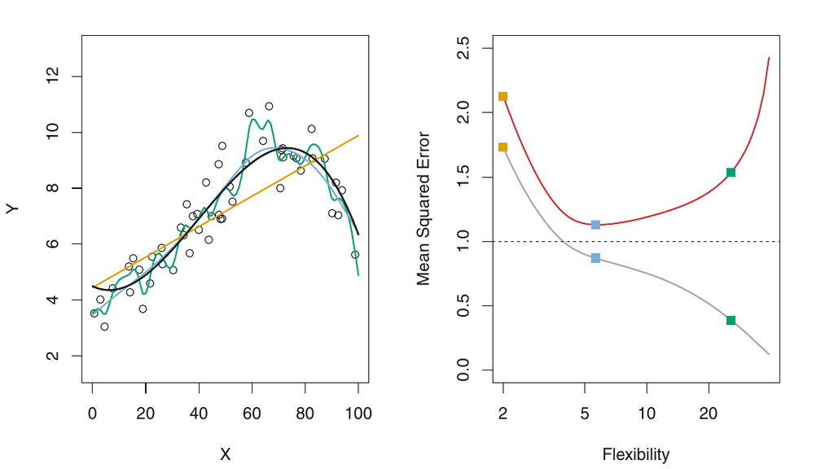

[figure not shown]

- High train performance, low test performance \(\Rightarrow\) **overfitting**;
- Our algorithim is working too hard and may be picking random pattern (\(\epsilon\)); \[ Y = f(X) + \epsilon \]
- It can be [shown](https://en.wikipedia.org/wiki/Bias%E2%80%93variance_tradeoff), the expected error can be decomposed as:

\[ E\left(y_0 - \hat{f}(x_0)\right)^2 = Var\left(\hat{f}(x_0)\right) + \left[Bias\left(\hat{f}(x_0)\right)\right]^2 + Var(\epsilon) \]

- *Variance* refers to amount by which \(\hat{f}\) would change if training set changes;
  - In general, more flexible ML methods have higher variance;
- *Bias* refer to the error: \(y_o - \hat{f}(x_0)\)
  - In general, more flexible ML methods have lower bias;
- As a **general rule**: as we use more flexible algorithms:

Variance \(\uparrow\) and Bias \(\downarrow\)

- The ultimate goal:

Finding an algorithm for which both (variance and bias) are low!

## Algorithms - Part 01

## The Bayes Classifier

- The Bayes Theorem states that

\[ P(y/X) = \frac{P(X/y)P(y)}{P(X)} \]

- The variable \(Y\) is the class variable and \(X\) represent \(p\) parameters/features;

\[ P(y/X_1, ..., X_p) = \frac{P(X_1/y)...P(X_p/y)P(Y)}{P(X_1)...P(X_p)} \]

- Notice that for each \(X\), the denominator does not change;

\[ P(y/X_1, ..., X_p) \propto P(X_1/y)...P(X_p/y)P(Y) \]

- Therefore, we need to find the class \(y\) for each \[ argmax_y \quad P(Y)\prod_{i=1}^pP(X_i/y) \]
- It can be shown that the solution yields to the **lowest test error**, called the *Bayes error rate*;

## Bayes Classifier

- In theory we would love to predict qualitative \(Y\) using the Bayes classifier;
- In the real world, conditional distribution of \(Y\) given \(X\) is unknown;
- Hence, the Bayes Classifier serves as *unattainable gold standard*;
- Many approaches attempt to *estimate the conditional distribution*;

## Linear Discriminant Analysis (LDA)

- Suppose we want to classify an *obs* into *K* classes (*K* \(\ge\) 2);
- Let \(\pi_k\) prior probability for the \(k_{th}\) class;
- Let \(f_k(X) = \text{P}(X = x/Y = k)\) the density funcion;
- Instead of computing \(\text{P}(Y = k/X = x)\), compute \(\pi_k\) and \(f_k(X)\);
- **Problem**: estimate \(f_k(X)\) is challenging.

## LDA

1. In order to estimate \(f_k(X)\), **assume** is *Gaussian*;
1. **Assume** that \(\sigma_1^2 = \sigma_2^2 = ... = \sigma_K^2 = \sigma^2\);
- Using (1) and (2):

\[ \text{p}_k(X) =\frac{ \pi_k \frac{1}{\sqrt{2\pi}\sigma} \text{exp}\left(- \frac{1}{2\sigma^2}(x - \mu_k)^2\right)}{ \sum_{l = 1}^K \pi_l \frac{1}{\sqrt{2\pi}\sigma} \text{exp}\left(- \frac{1}{2\sigma^2}(x - \mu_l)^2\right)} \]

- **Rule**: assign an observation with \(X = x\) where \(\text{p}_k(X)\) is largest.

## Quadratic Discriminant Analysis (QDA)

- LDA assumes multivariate *Gaussian* distribution;
1. QDA also assumes multivariate *Gaussian* distribution;
1. However, each class has its own covariance matrix:

\[ X \sim \mathcal{N}\left(\mu_k, \Sigma_k\right) \]

- Using (1) and (2):

\[ \text{p}_k(X) =\frac{ \pi_k \frac{1}{\sqrt{2\pi\sigma_k^2}} \text{exp}\left(- \frac{1}{2\sigma_k^2}(x - \mu_k)^2\right)}{ \sum_{l = 1}^K \pi_l \frac{1}{\sqrt{2\pi\sigma_l^2}} \text{exp}\left(- \frac{1}{2\sigma_l^2}(x - \mu_l)^2\right)} \]

## LDA vs QDA?

- *Answer*: bias variance trade-off;
- LDA : less flexible (more bias), but less variance;
- QDA : more flexible (less bias), but more variance;
- LDA tends to be better if there is few training: reduce variance is critical;
- QDA is recomended if training set is very large and common variance assumption is untenable.

## K-Nearest Neighbors

- Another attempt to estimate the distribution of \(Y\) given \(X\);
- Let \(K\) be a positive integer and a test *obs* \(x_0\);
- *KNN* identifies \(K\) points in the traning data that are closest to \(x_0\) represented by \(\mathcal{N}_0\);
- It estimates the conditional probability for class \(j\) as \[ P(Y = j/X = x_0) = \frac{1}{K} \sum_{i \in \mathcal{N}_0} I(y_i = j) \]
- Finally, *KNN* classifies the test *obs* \(x_0\) to the class with largest probability;

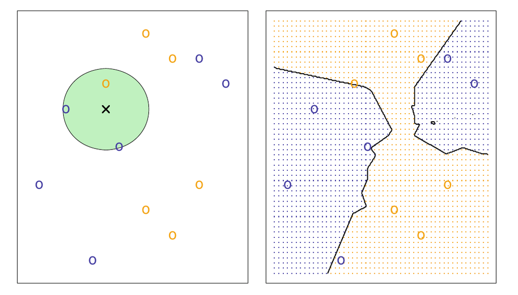

## KNN

- The choice of \(K\) has a drastic effect on the KNN classifier;
- As \(K\) grows, the method becomes *less flexible* and produce decision boundary close to linear;
- This correspond to a low-variance but high-bias classifier;

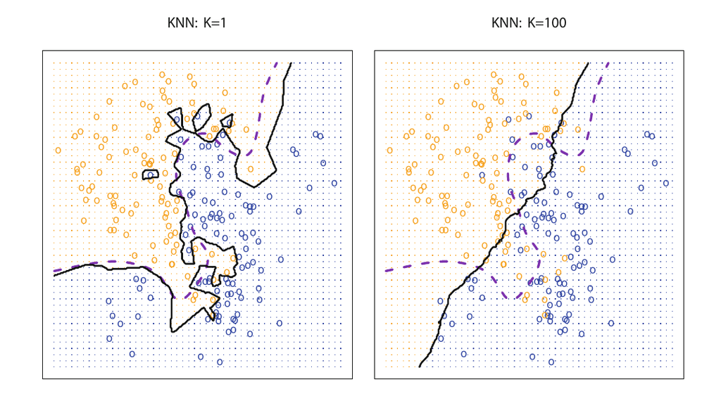

## Penalized methods

- A simple machine learning model familiar to us: **linear model**:

\[ Y = X\beta + \epsilon \]

- Remember that we choose the parameter vector \(\beta \in \mathcal{R}^P\) such as \[ \hat{\beta}^{OLS} = argmin_{\beta} \quad \sum_{i}^N(Y_i - X_i^T\beta)^2 \]
- The solution yields to \(\hat{\beta}^{OLS} = (X^TX)^{-1}X^TY\);
- When \(N > P\), this solution is well defined;
- However, when \(P\) is large, OLS solution is at risk of **overfitting**;
- Worse: if \(P \gt N\), there is no longer a unique solution and variance is tends to infinity;
- **Solution**: by shrinking (penalizing) the estimated coefficients, we can reduce the variance at the cost of a negligible increase in bias.

## Penalized methods

- These approaches involve fitting a model involving all \(P\) predictors, even for \(P > N\);
- However, the estimated coefficients are *shrunken* towards zero relative to the OLS estimates;
- This shrinkage has the effect of **reducing variance**;
- Depending on what type of shrinkage, some of the coefficients may be estimated to be exactly zero;

[figure not shown]

- The best-known techniques for shrinking the coefficients are:
  - Ridge;
  - LASSO;
  - Elastic net.

## Penalized methods: Ridge

- Recall that OLS estimates \(\hat{\beta}^{OLS}\) by minimizing \[ \text{RSS} = \sum_{i=1}^N (Y_i - X_i^T\beta)^2 \]
- **Ridge** algorithm will estimate \(\hat{\beta}^{ridge}\) by minimizing

\[ \sum_{i=1}^N (Y_i - X_i^T\beta)^2 + \lambda\sum_{j=1}^P \beta_j^2 \\ \text{RSS} + \lambda\sum_{j=1}^P \beta_j^2 \]

- where \(\lambda\) is a **tunning parameter**;
- Unlike least squares, ridge regression will produce a different \(\hat{\beta}^{ridge}\) for each value of \(\lambda\);
- Selecting a good value for \(\lambda\) is critical.

## Penalized methods: LASSO

- The Ridge algorithm will include all \(P\) predictors in the final model;
- The penalty \(\lambda \sum_{i=1}^N \beta^2\) will shrink all of the coefficients towards zero;
- the **LASSO** algorithm will estimate \(\hat{\beta}^{LASSO}\) by minimizing

\[ \sum_{i=1}^N (Y_i - X_i^T\beta)^2 + \lambda \sum_{j=1}^P |\beta_j| \\ \text{RSS} + \lambda \sum_{j=1}^P |\beta_j| \]

- As with Ridge algorithm, the LASSO shrinks the coefficient estimates towards zero;
- However, the \(l_1\) penalty has the effect of forcing some of the coefficient estimates to be exactly zero;
- Hence, the LASSO yields **sparse models**.

## Another formulation for Ridge and LASSO

- One can show that \(\hat{\beta}^{ridge}\) and \(\hat{\beta}^{LASSO}\) solve the following problems

\[ \hat{\beta}^{ridge} = argmin_{\beta} \, \sum_{i=1}^N (Y_i - X_i^T\beta)^2 \\ \text{subject to} \quad \sum_{j=1}^P \beta_j^2 \le s \]

\[ \hat{\beta}^{LASSO} = argmin_{\beta} \, \sum_{i=1}^N (Y_i - X_i^T\beta)^2 \\ \text{subject to} \quad \sum_{j=1}^P |\beta_j| \le s \]

- In other words, for every value of \(\lambda\), there is some \(s\) such that will give the \(\hat{\beta}^{ridge}\) and \(\hat{\beta}^{LASSO}\);

## Another formulation for Ridge and LASSO

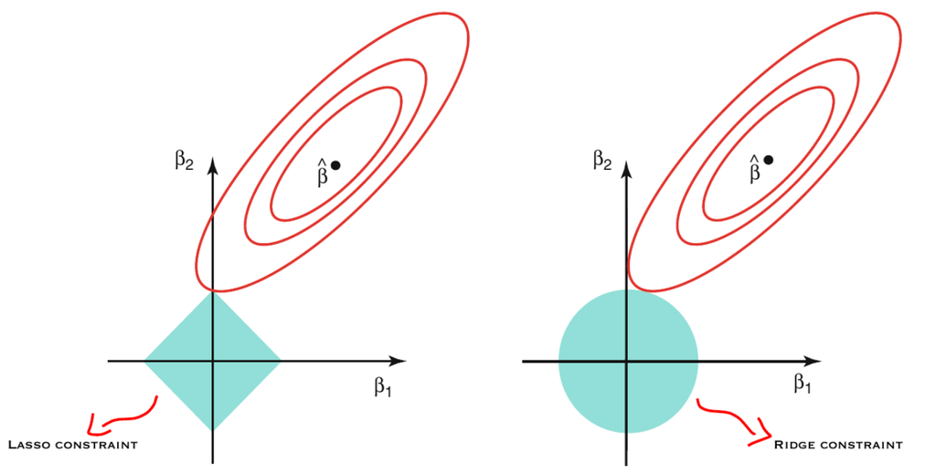

## Penalized methods: Elastic net

- Elastic net is an algorithm which involves the \(l_1\) and \(l_2\) penalty norms;
- This algorithm method aims to overcome some limitations of the LASSO;
- For instance, if there is a group of highly correlated variables, then the LASSO tends to select one variable;
- The estimates from the elastic net method are defined by

\[ \hat{\beta}^{EN} = argmin_\beta \sum_{i=1}^N (Y_i - X_i^T\beta)^2 + \lambda \left[ \left(\frac{1 - \alpha}{2}\right) \sum_{j=1}^P (\beta_j)^2 + \alpha \sum_{j=1}^P |\beta_j|\right] \]

- Where \(\alpha\) and \(\lambda\) are tunning parameters;
- The quadratic penalty term makes the loss function strictly convex, and it therefore has a unique minimum;
- The elastic net method includes the LASSO and ridge algorithm.

## Wrapup

**Any questions**?